# Introdução

Os dados que serão usados, são importados do **Kaggle**, les foram disponibilizados pelo usuário **NIDULA ELGIRIYEWITHANA**, e foi atualizado pela última vez em 30 de setembro de 2023. Serão com eles que iremos inicialmente ver a distribuição de riqueza por tipo industria e sexo.

### Metodologia

Não terá metodologia definida, pois, será de acordo com o andamento e questionamentos que surgirão.

### Importando bibliotecas

Primeiramente devemos importar as bibliotecas que iremos usar, como o pandas que usaremos para ler e manipular os dados.

```python
import pandas as pd
```

### Iendo o arquivo

Depois de importar o pandas fazemos a leitura do arquivo Billionaires Statistics Dataset.csv

```python
df = pd.read_csv('Billionaires Statistics Dataset.csv')
```

### Impressão dos dados

Imprimiremos as primeiros 5 linhas, assim dando uma analize inicial dos dados.

```python
df.head()
```

|  | rank | finalWorth | category | personName | age | country | city | source | industries | countryOfCitizenship | ... | cpi_change_country | gdp_country | gross_tertiary_education_enrollment | gross_primary_education_enrollment_country | life_expectancy_country | tax_revenue_country_country | total_tax_rate_country | population_country | latitude_country | longitude_country |
| --- | --- | --- | --- | --- | --- | --- | --- | --- | --- | --- | --- | --- | --- | --- | --- | --- | --- | --- | --- | --- | --- |
| 0 | 1 | 211000 | Fashion & Retail | Bernard Arnault & family | 74.0 | France | Paris | LVMH | Fashion & Retail | France | ... | 1.1 | $2,715,518,274,227 | 65.6 | 102.5 | 82.5 | 24.2 | 60.7 | 67059887.0 | 46.227638 | 2.213749 |
| 1 | 2 | 180000 | Automotive | Elon Musk | 51.0 | United States | Austin | Tesla, SpaceX | Automotive | United States | ... | 7.5 | $21,427,700,000,000 | 88.2 | 101.8 | 78.5 | 9.6 | 36.6 | 328239523.0 | 37.090240 | -95.712891 |
| 2 | 3 | 114000 | Technology | Jeff Bezos | 59.0 | United States | Medina | Amazon | Technology | United States | ... | 7.5 | $21,427,700,000,000 | 88.2 | 101.8 | 78.5 | 9.6 | 36.6 | 328239523.0 | 37.090240 | -95.712891 |
| 3 | 4 | 107000 | Technology | Larry Ellison | 78.0 | United States | Lanai | Oracle | Technology | United States | ... | 7.5 | $21,427,700,000,000 | 88.2 | 101.8 | 78.5 | 9.6 | 36.6 | 328239523.0 | 37.090240 | -95.712891 |
| 4 | 5 | 106000 | Finance & Investments | Warren Buffett | 92.0 | United States | Omaha | Berkshire Hathaway | Finance & Investments | United States | ... | 7.5 | $21,427,700,000,000 | 88.2 | 101.8 | 78.5 | 9.6 | 36.6 | 328239523.0 | 37.090240 | -95.712891 |

5 rows × 35 columns

### Visão geral

Olhando pela primeira vez pode-se notar que a quantidade total de colunas não pode ser vista devido a quantidade, tendo isso em vista, iremos ver a quantidade total de colunas e linhas, e o nome das colunas.

```python
print('Quantidade de colunas:\t',df.shape[1],'\nQuantidade de linhas:\t',df.shape[0])
```

```
Quantidade de colunas:	 35
Quantidade de linhas:	 2640
```

```python
df.columns
```

```
Index(['rank', 'finalWorth', 'category', 'personName', 'age', 'country',
       'city', 'source', 'industries', 'countryOfCitizenship', 'organization',
       'selfMade', 'status', 'gender', 'birthDate', 'lastName', 'firstName',
       'title', 'date', 'state', 'residenceStateRegion', 'birthYear',
       'birthMonth', 'birthDay', 'cpi_country', 'cpi_change_country',
       'gdp_country', 'gross_tertiary_education_enrollment',
       'gross_primary_education_enrollment_country', 'life_expectancy_country',
       'tax_revenue_country_country', 'total_tax_rate_country',
       'population_country', 'latitude_country', 'longitude_country'],
      dtype='object')
```

### Simplificando o Data Frame

Para responder a nossa questão inicial não precisamos de algumas colunas como: 'latitude_country', 'longitude_country', pois, elas indicam longitude e latitude, Alem de outras colunas que não usaremos inicialmente. Essa simplificação sera chamada **df_simple**.

Para fazer isso seguiremos os seguintes passos:

- Selecionar as colunas que queremos
- Passar essa seleção para variável nova

```python
df_simple = df[['rank','category', 'personName', 'age', 'country','source', 'status','gender','finalWorth']]
```

### Significado das colunas

- **rank**: A classificação dos bilionários em termos de riqueza.
- **category**: A categoria ou sector em que a empresa do bilionário opera.
- **personName**: O nome completo do bilionário.
- **age**: A era do bilionário.
- **country**: O país em que o bilionário reside.
- **source**: A origem da riqueza do bilionário.
- **status**: O "D" representa os bilionários que se fizeram a si próprios (fundadores/empresários) e o "U" indica a riqueza herdada ou não adquirida.
- **gender**: O género do bilionário.
- **finalWorth**: O património líquido final do bilionário em dólares americanos.

### Impressão da simplificação

```python
df_simple
```

|  | rank | category | personName | age | country | source | status | gender | finalWorth |
| --- | --- | --- | --- | --- | --- | --- | --- | --- | --- |
| 0 | 1 | Fashion & Retail | Bernard Arnault & family | 74.0 | France | LVMH | U | M | 211000 |
| 1 | 2 | Automotive | Elon Musk | 51.0 | United States | Tesla, SpaceX | D | M | 180000 |
| 2 | 3 | Technology | Jeff Bezos | 59.0 | United States | Amazon | D | M | 114000 |
| 3 | 4 | Technology | Larry Ellison | 78.0 | United States | Oracle | U | M | 107000 |
| 4 | 5 | Finance & Investments | Warren Buffett | 92.0 | United States | Berkshire Hathaway | D | M | 106000 |
| ... | ... | ... | ... | ... | ... | ... | ... | ... | ... |
| 2635 | 2540 | Healthcare | Yu Rong | 51.0 | China | Health clinics | D | M | 1000 |
| 2636 | 2540 | Food & Beverage | Richard Yuengling, Jr. | 80.0 | United States | Beer | E | M | 1000 |
| 2637 | 2540 | Manufacturing | Zhang Gongyun | 60.0 | China | Tyre manufacturing machinery | R | M | 1000 |
| 2638 | 2540 | Real Estate | Zhang Guiping & family | 71.0 | China | Real estate | D | M | 1000 |
| 2639 | 2540 | Diversified | Inigo Zobel | 66.0 | Philippines | Diversified | R | M | 1000 |

2640 rows × 9 columns

### Comparação dos dados

Comparação dos dois data frames, comparando o numero de colunas e linhas.

```python
print('Sem simplificação','\nColunas:\t',df.shape[1],'\nLinhas:\t\t',df.shape[0],'\n',
      '\nCom simplificação','\nColunas:\t',df_simple.shape[1],'\nLinhas:\t\t',df_simple.shape[0])
print('\nDiferença:\t',(df.shape[1] - df_simple.shape[1]))
```

```
Sem simplificação
Colunas:	 35
Linhas:		 2640

Com simplificação
Colunas:	 9
Linhas:		 2640

Diferença:	 26
```

### Descrição dos dados

Será usado a função describe, ela tem a função de mostrar informações usando os dados numéricos.

```python
df_simple.describe()
```

|  | rank | age | finalWorth |
| --- | --- | --- | --- |
| count | 2640.000000 | 2575.000000 | 2640.000000 |
| mean | 1289.159091 | 65.140194 | 4623.787879 |
| std | 739.693726 | 13.258098 | 9834.240939 |
| min | 1.000000 | 18.000000 | 1000.000000 |
| 25% | 659.000000 | 56.000000 | 1500.000000 |
| 50% | 1312.000000 | 65.000000 | 2300.000000 |
| 75% | 1905.000000 | 75.000000 | 4200.000000 |
| max | 2540.000000 | 101.000000 | 211000.000000 |

**Significado da descrição:**

- **count**: Fas soma das quantidade dos valores, porem, não conta valores nulos.
- **mean**: É a medía dos valores.
- **std**: É o desvio padrão.
- **min**: O valor minimo existente.
- **25%**: É o valor que esta no meio entre o valor minimo e a mediana
- **50%**: É a mediana, ou seja, o valor que esta no meio entre a duas estremidades
- **75%**: É o valor que esta no meio entre a mediana eo maximo
- **max**: O valor maximo.

```python
sum(df_simple['age'].isnull())
```

```
65
```

acima foi feito uma soma dos valores nulos existentes.

```python
df_simple[df_simple['age'].isnull()]
```

|  | rank | category | personName | age | country | source | status | gender | finalWorth |
| --- | --- | --- | --- | --- | --- | --- | --- | --- | --- |
| 107 | 108 | Fashion & Retail | Karl Albrecht Jr. & family | NaN | Germany | Supermarkets | Split Family Fortune | M | 15800 |
| 108 | 108 | Fashion & Retail | Beate Heister | NaN | NaN | Supermarkets | Split Family Fortune | F | 15800 |
| 247 | 246 | Finance & Investments | Francine von Finck & family | NaN | Switzerland | Investments | D | F | 8300 |
| 550 | 534 | Real Estate | Zhu Yan & family | NaN | China | Real estate | U | F | 5000 |
| 554 | 552 | Technology | Marcos Galperin | NaN | Argentina | E-commerce | U | M | 4900 |
| ... | ... | ... | ... | ... | ... | ... | ... | ... | ... |
| 2452 | 2405 | Finance & Investments | Christian Herz | NaN | Germany | Coffee | E | M | 1100 |
| 2453 | 2405 | Finance & Investments | Michaela Herz | NaN | Germany | Coffee | E | F | 1100 |
| 2550 | 2540 | Logistics | Chang Kuo-Ming | NaN | Taiwan | Transportation | D | M | 1000 |
| 2603 | 2540 | Manufacturing | Gabriella Meister | NaN | Germany | Appliances | D | F | 1000 |
| 2609 | 2540 | Fashion & Retail | Réal Plourde | NaN | Canada | Convenience stores | N | M | 1000 |

65 rows × 9 columns

### tratando valores

Valores nulos podem ser tratados de acordo com a sua necessidade. Para a nossa analise basta substituir eles pela mediana de idade dos bilionarios ja que assim o seu valor não interferira nos nossos calculos, pois, temos mais de duas mil linhas, então substituir não mudara significamente o resultado final.

**Substituindo os valores nulos**

irei substituir os valores nulos da coluna age(idade) pela idade mediana. Mudaremos pela mediana, já que, pela media traria um valor "quebrado" (ex: 65,3).

```python
#mediana dos valores da coluna "age"
df_simple['age'].median()
```

```
65.0
```

```python
df_simple = df_simple.fillna(df_simple['age'].median())
```

Agora verificamos se ainda tem-se valores nulos

```python
df_simple[df_simple['age'].isnull()]
```

|  | rank | category | personName | age | country | source | status | gender | finalWorth |
| --- | --- | --- | --- | --- | --- | --- | --- | --- | --- |

```python
sum(df_simple['age'].isnull())
```

```
0
```

```python
#usando rank para imprimir onde tinham valores nulos
df_simple[df_simple['rank'] == 108]. head(1)
```

|  | rank | category | personName | age | country | source | status | gender | finalWorth |
| --- | --- | --- | --- | --- | --- | --- | --- | --- | --- |
| 107 | 108 | Fashion & Retail | Karl Albrecht Jr. & family | 65.0 | Germany | Supermarkets | Split Family Fortune | M | 15800 |

Após tratar valores nulos podemos começar a imprimir e analisar visualmente como os dados estão.

### Imprimindo gráficos

Para imprimir os gráficos precisamos primeiramente importar a biblioteca matplotlib, após sua importação, começaremos imprimindo gráficos. Além da biblioteca dos gráficos será usado a biblioteca numpy, que é focada em usos matemáticos.

```python
import matplotlib.pyplot as plt
import numpy as np
```

**Gráficos baseados em gênero**

Nesse gráfico tem a riqueza do homem mais rico e da mulher mais rica

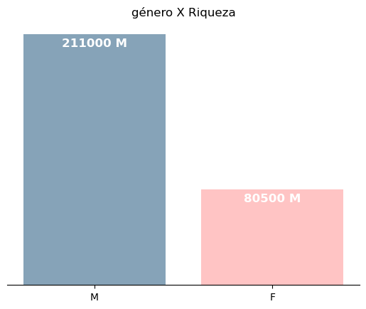

```python
#cores:
#azul = #86A3B8
#roza = #FFC4C4

valorMasculino = df_simple.groupby('gender')['finalWorth'].max().index[1]
finalWorthMasculino = df_simple.groupby('gender')['finalWorth'].max().values[1]
valorFeminino =  df_simple.groupby('gender')['finalWorth'].max().index[0]
finalWorthFeminino = df_simple.groupby('gender')['finalWorth'].max().values[0]

fig, ax = plt.subplots()
ax.bar(valorMasculino, finalWorthMasculino, label='M-Masculino',color='#86A3B8')
ax.bar(valorFeminino,finalWorthFeminino, label='F-Feminino',color='#FFC4C4')

ax.yaxis.set_visible(False)
ax.spines['top'].set_visible(False)
ax.spines['right'].set_visible(False)
ax.spines['left'].set_visible(False)

ax.annotate((str(finalWorthFeminino) + ' M'),
            xy=(1,(finalWorthFeminino - 10500)),ha='center', fontsize=12, fontweight='bold', color='w')
ax.annotate((str(finalWorthMasculino)+' M'),
            xy=(0,(finalWorthMasculino - 10500)),ha='center', fontsize=12, fontweight='bold', color='w')

plt.title('género X Riqueza')

plt.show()
```

Pode-se observar a diferença entre os dois mais ricos

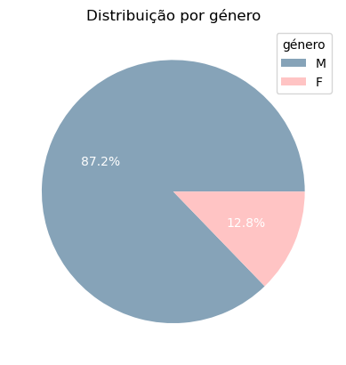

```python
totalGenero = df_simple['gender'].value_counts()

fig, ax = plt.subplots()
ax.pie(totalGenero, labels=totalGenero.index, autopct='%1.1f%%', colors=['#86A3B8', '#FFC4C4'], textprops=dict(color="w"))

ax.set_title("Distribuição por género")
ax.legend(title="género")

plt.show()
```

Tem-se muito mais homens ricos do que mulheres ricas.

**Imprimindo outros graficos**

Graficos apenas para demontrar diferentes dados que podem ser usados como:

- Distribuição da quantidade bilionários de acordo com os seus países.

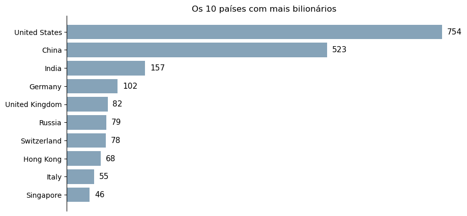

```python
top10Paises = df_simple.country.value_counts().head(10)

fig, ax = plt.subplots(figsize=(10, 5))
ax.barh(top10Paises.index,top10Paises.values, color='#86A3B8')

ax.set_title('Os 10 países com mais bilionários')

for i in np.arange(0,10):
    ax.annotate(top10Paises.values[i],(top10Paises.values[i] + 10,i), va='center', fontsize=11)

ax.xaxis.set_visible(False)
ax.spines['top'].set_visible(False)
ax.spines['right'].set_visible(False)
ax.spines['bottom'].set_visible(False)

ax.invert_yaxis()

plt.show()
```

- As categorias usadas pelos 100 mais ricos.

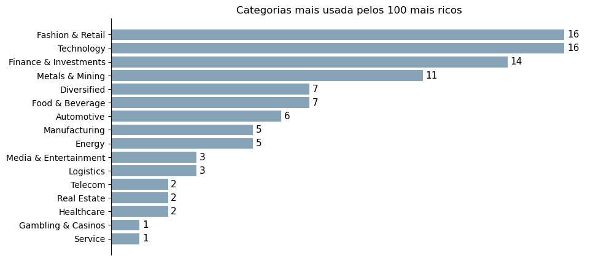

```python
melhores_100 = df_simple.loc[:100,["finalWorth","category","country"]]

negocios = melhores_100['category'].value_counts()

fig, ax = plt.subplots(figsize=(10, 5))
ax.barh(negocios.index,negocios.values, color='#86A3B8')

ax.set_title('Categorias mais usada pelos 100 mais ricos')

for i in np.arange(0,16):
    ax.annotate(negocios.values[i],(negocios.values[i] + 0.1,i), va='center', fontsize=11)

ax.spines['top'].set_visible(False)
ax.spines['right'].set_visible(False)
ax.spines['bottom'].set_visible(False)
ax.xaxis.set_visible(False)

ax.invert_yaxis()

ax.tick_params(axis='x', rotation=0)

plt.show()
```

### Conclusão

Ao observar esses gráficos pode-se perceber a grande diferença entre a distribuição de riquezas entre homens e mulheres que se deve a grande parte dos empresários serem homens, não só isso como vimos que a diferença entre o homem mais rico da lista comparada com a mulher também com o maior capital, podendo ver assim que mesmo os dois sendo os mais ricos do seu gênero tem-se uma diferença tão grande.